# [Chapter 13] The final online shopping purchase intent predictions

[DSLC stages]: Analysis

The following code sets up the libraries and creates cleaned and pre-processed training, validation and test data that we will use in this document.

```r
# loading libraries
library(patchwork)
library(lubridate)
library(scales)
library(yardstick)
library(fastDummies)
library(tidyverse)
library(janitor)
library(ranger)
# apply the cleaning and pre-processing functions
source("functions/prepareShoppingData.R")
# list all objects (and custom functions) that exist in our environment
ls()
```

```
 [1] "browser_levels"                      "operating_systems_levels"
 [3] "preprocessShoppingData"              "shopping_orig"
 [5] "shopping_test"                       "shopping_test_preprocessed"
 [7] "shopping_train"                      "shopping_train_preprocessed"
 [9] "shopping_train_preprocessed_nodummy" "shopping_val"
[11] "shopping_val_preprocessed"           "shopping_val_preprocessed_nodummy"
[13] "traffic_type_levels"
```

In this document we will demonstrate how to use the principles of PCS to choose the final prediction. We will demonstrate two different formats of the final prediction based on:

1. The **single “best”** predictive algorithm, in terms of validation set performance from among a range of different algorithms each trained on several different cleaning/pre-processing judgment call-perturbed versions of the training dataset.
2. An **ensemble** prediction, which combines the predictions from a range of predictive fits from across different algorithms and cleaning/pre-processing judgment call-perturbations that pass a predictability screening test.

Note that we do not compute PCS **prediction perturbation intervals** for binary response predictions, because although we can compute intervals for our class probability predictions, we cannot calibrate them (and so our interpretation will necessarily be heavily influenced by the number of perturbations that we consider).

## 1 Computing the perturbed predictions

Since each of these approaches will involve each perturbed version of the cleaning/pre-processing judgment call training (and validation) datasets that we used in our stability analyses, we will create the cleaning/pre-processing judgment call-perturbed datasets and fit the algorithms here.

### 1.1 Create the perturbed datasets

First, let’s create the tibble containing the cleaning/pre-processing judgment call perturbed datasets:

```r
numeric_to_cat = c(TRUE, FALSE)
month_numeric <- c(TRUE, FALSE)
log_page <- c(TRUE, FALSE)
remove_extreme <- c(TRUE, FALSE)
param_options <- expand_grid(numeric_to_cat,
                             month_numeric,
                             log_page,
                             remove_extreme)
# create the perturbed datasets in a list column
shopping_jc_perturbed <- param_options %>%
  rowwise() %>%
  # add training data list column
  mutate(data_train_perturbed =
           list(preprocessShoppingData(shopping_train,
                                    .numeric_to_cat = numeric_to_cat,
                                    .month_numeric = month_numeric,
                                    .log_page = log_page,
                                    .remove_extreme = remove_extreme))) %>%
  # create a version of the training data cat levels for matching val set to train set
  mutate(data_train_perturbed_nodummy =
           list(preprocessShoppingData(shopping_train,
                                    .numeric_to_cat = numeric_to_cat,
                                    .month_numeric = month_numeric,
                                    .log_page = log_page,
                                    .remove_extreme = remove_extreme,
                                    .dummy = FALSE))) %>%
  # extract the levels to use for ensuring the validation sets match the training set
  mutate(browser_levels =
           list(levels(data_train_perturbed_nodummy$browser)),
         operating_systems_levels =
           list(levels(data_train_perturbed_nodummy$operating_systems)),
         traffic_type_levels =
           list(levels(data_train_perturbed_nodummy$traffic_type))) %>%
  # add validation data list column
  mutate(data_val_perturbed =
           list(preprocessShoppingData(shopping_val,
                                    .numeric_to_cat = numeric_to_cat,
                                    .month_numeric = month_numeric,
                                    .log_page = log_page,
                                    # note that since we want to ensure that all
                                    # fits are compared on the same set of data
                                    # points, we need to remove the extreme data
                                    # points for all perturbations
                                    .remove_extreme = TRUE,
                                    # make sure val columns match train columns
                                    .column_selection = colnames(data_train_perturbed),
                                    .operating_systems_levels = operating_systems_levels,
                                    .browser_levels = browser_levels,
                                    .traffic_type_levels = traffic_type_levels,
                                    .id = TRUE)))  |>
    # add test data list column
  mutate(data_test_perturbed =
           list(preprocessShoppingData(shopping_test,
                                    .numeric_to_cat = numeric_to_cat,
                                    .month_numeric = month_numeric,
                                    .log_page = log_page,
                                    # note that since we want to ensure that all
                                    # fits are compared on the same set of data
                                    # points, we need to remove the extreme data
                                    # points for all perturbations
                                    .remove_extreme = TRUE,
                                    # make sure val columns match train columns
                                    .column_selection = colnames(data_train_perturbed),
                                    .operating_systems_levels = operating_systems_levels,
                                    .browser_levels = browser_levels,
                                    .traffic_type_levels = traffic_type_levels,
                                    .id = TRUE))) |>
  select(-data_train_perturbed_nodummy,
         -browser_levels, -operating_systems_levels, -traffic_type_levels)

# look at the object we just created
print(shopping_jc_perturbed, width = Inf)
```

```
# A tibble: 16 × 7
# Rowwise:
   numeric_to_cat month_numeric log_page remove_extreme data_train_perturbed
   <lgl>          <lgl>         <lgl>    <lgl>          <list>
 1 TRUE           TRUE          TRUE     TRUE           <tibble [7,361 × 46]>
 2 TRUE           TRUE          TRUE     FALSE          <tibble [7,372 × 46]>
 3 TRUE           TRUE          FALSE    TRUE           <tibble [7,361 × 46]>
 4 TRUE           TRUE          FALSE    FALSE          <tibble [7,372 × 46]>
 5 TRUE           FALSE         TRUE     TRUE           <tibble [7,361 × 54]>
 6 TRUE           FALSE         TRUE     FALSE          <tibble [7,372 × 54]>
 7 TRUE           FALSE         FALSE    TRUE           <tibble [7,361 × 54]>
 8 TRUE           FALSE         FALSE    FALSE          <tibble [7,372 × 54]>
 9 FALSE          TRUE          TRUE     TRUE           <tibble [7,361 × 18]>
10 FALSE          TRUE          TRUE     FALSE          <tibble [7,372 × 18]>
11 FALSE          TRUE          FALSE    TRUE           <tibble [7,361 × 18]>
```

[output cut: 23 more lines]

### 1.2 Fitting the algorithms to each perturbed dataset

Let’s create a column for the LS (applied to a binary response problem), logistic regression, and RF algorithms, each trained using each judgment call-perturbed version of the training data (i.e., one for each row). Then we will add a column containing the predictions for each fit.

```r
# this will take a little while to run
set.seed(299433)
perturbed_jc_pred <- shopping_jc_perturbed %>%
  ungroup() %>%
  # to speed up the computation, you can uncomment the lines below to do the
  # analysis for just a random subset of judgment call combinations
  # your conclusions might differ slightly though
  # sample_n(50) %>%
  rowwise() %>%
  # fit each algorithm (lasso and ridge will be fit below) and store them each
  # in a column
  mutate(ls = list(lm(parse_number(as.character(purchase)) ~ ., data_train_perturbed)),
         lr = list(glm(factor(purchase, levels = c(0, 1)) ~ ., data_train_perturbed,
                       family = "binomial")),
         rf = list(ranger(purchase  ~ ., data_train_perturbed, probability = TRUE))) %>%
  # compute validation set predictions for each algorithm
  mutate(pred_val_ls = list(predict(ls, data_val_perturbed)),
         pred_val_lr = list(predict(lr, data_val_perturbed, type = "response")),
         pred_val_rf = list(predict(rf, data_val_perturbed)$predictions[, 1])) %>%
  # compute test set predictions for each algorithm
  mutate(pred_test_ls = list(predict(ls, data_test_perturbed)),
         pred_test_lr = list(predict(lr, data_test_perturbed, type = "response")),
         pred_test_rf = list(predict(rf, data_test_perturbed)$predictions[, 1])) %>%
  # add a column with just the actual observed sale price value
  mutate(true_val = list(data_val_perturbed$purchase),
         true_test = list(data_test_perturbed$purchase),
         # add a column for the session ids
         id_val = list(data_val_perturbed$id),
         id_test = list(data_test_perturbed$id))

print(perturbed_jc_pred, width = Inf)
```

```
# A tibble: 16 × 20
# Rowwise:
   numeric_to_cat month_numeric log_page remove_extreme data_train_perturbed
   <lgl>          <lgl>         <lgl>    <lgl>          <list>
 1 TRUE           TRUE          TRUE     TRUE           <tibble [7,361 × 46]>
 2 TRUE           TRUE          TRUE     FALSE          <tibble [7,372 × 46]>
 3 TRUE           TRUE          FALSE    TRUE           <tibble [7,361 × 46]>
 4 TRUE           TRUE          FALSE    FALSE          <tibble [7,372 × 46]>
 5 TRUE           FALSE         TRUE     TRUE           <tibble [7,361 × 54]>
 6 TRUE           FALSE         TRUE     FALSE          <tibble [7,372 × 54]>
 7 TRUE           FALSE         FALSE    TRUE           <tibble [7,361 × 54]>
 8 TRUE           FALSE         FALSE    FALSE          <tibble [7,372 × 54]>
 9 FALSE          TRUE          TRUE     TRUE           <tibble [7,361 × 18]>
10 FALSE          TRUE          TRUE     FALSE          <tibble [7,372 × 18]>
11 FALSE          TRUE          FALSE    TRUE           <tibble [7,361 × 18]>
```

[output cut: 59 more lines]

Next, let’s create a long-form version of this tibble, which contains a single row for each of the perturbed algorithms that we fit, and compute the performance measures.

```r
perturbed_jc_performance <- perturbed_jc_pred |>
  ungroup() |>
  # select the relevant validation set prediction performance
  select(# judgment calls
    numeric_to_cat, month_numeric, log_page, remove_extreme,
    # val predictions
    pred_val_ls, pred_val_lr, pred_val_rf,
    # val truth
    true_val) |>
  # pivot to a long-form version with one column for all the predictions
  pivot_longer(cols = c("pred_val_ls", "pred_val_lr", "pred_val_rf"),
               names_to = "algorithm",
               values_to = "pred_val",
               names_prefix = "pred_val_") %>%
  rowwise() %>%
  # undo the log transformation where relevant
  mutate(pred_val_binary = list(factor(as.numeric(pred_val >= 0.161), levels = c(1, 0)))) |>
  # add performance metrics for each perturbed fit
  mutate(accuracy = accuracy_vec(true_val, pred_val_binary),
         tp_rate = sens_vec(true_val, pred_val_binary),
         tn_rate = spec_vec(true_val, pred_val_binary),
         auc = roc_auc_vec(true_val, pred_val))

print(perturbed_jc_performance, width = Inf)
```

```
# A tibble: 48 × 12
# Rowwise:
   numeric_to_cat month_numeric log_page remove_extreme true_val      algorithm
   <lgl>          <lgl>         <lgl>    <lgl>          <list>        <chr>
 1 TRUE           TRUE          TRUE     TRUE           <fct [2,453]> ls
 2 TRUE           TRUE          TRUE     TRUE           <fct [2,453]> lr
 3 TRUE           TRUE          TRUE     TRUE           <fct [2,453]> rf
 4 TRUE           TRUE          TRUE     FALSE          <fct [2,453]> ls
 5 TRUE           TRUE          TRUE     FALSE          <fct [2,453]> lr
 6 TRUE           TRUE          TRUE     FALSE          <fct [2,453]> rf
 7 TRUE           TRUE          FALSE    TRUE           <fct [2,453]> ls
 8 TRUE           TRUE          FALSE    TRUE           <fct [2,453]> lr
 9 TRUE           TRUE          FALSE    TRUE           <fct [2,453]> rf
10 TRUE           TRUE          FALSE    FALSE          <fct [2,453]> ls
   pred_val      pred_val_binary accuracy tp_rate tn_rate   auc
   <list>        <list>             <dbl>   <dbl>   <dbl> <dbl>
 1 <dbl [2,453]> <fct [2,453]>      0.759   0.895   0.736 0.903
 2 <dbl [2,453]> <fct [2,453]>      0.816   0.787   0.821 0.897
 3 <dbl [2,453]> <fct [2,453]>      0.841   0.873   0.836 0.934
 4 <dbl [2,453]> <fct [2,453]>      0.758   0.898   0.734 0.903
 5 <dbl [2,453]> <fct [2,453]>      0.816   0.787   0.821 0.896
 6 <dbl [2,453]> <fct [2,453]>      0.848   0.881   0.842 0.934
 7 <dbl [2,453]> <fct [2,453]>      0.773   0.892   0.752 0.905
 8 <dbl [2,453]> <fct [2,453]>      0.826   0.798   0.831 0.899
 9 <dbl [2,453]> <fct [2,453]>      0.847   0.881   0.841 0.935
10 <dbl [2,453]> <fct [2,453]>      0.770   0.892   0.750 0.906
# ℹ 38 more rows
```

## 2 Approach 1: Choosing a single predictive fit using PCS

Having computed the performance of each of our judgment-call perturbed fits for each algorithm we considered in this book, we can then identify which fit yields the “best” performance.

The following code prints the details of the fits with the highest AUC performance:

```r
shopping_top_auc <- perturbed_jc_performance %>%
  arrange(desc(auc)) %>%
  select(algorithm, numeric_to_cat, month_numeric, log_page, remove_extreme,
         accuracy, tp_rate, tn_rate, auc)
print(head(shopping_top_auc), width = Inf)
```

```
# A tibble: 6 × 9
# Rowwise:
  algorithm numeric_to_cat month_numeric log_page remove_extreme accuracy
  <chr>     <lgl>          <lgl>         <lgl>    <lgl>             <dbl>
1 rf        FALSE          FALSE         FALSE    TRUE              0.855
2 rf        FALSE          FALSE         TRUE     TRUE              0.853
3 rf        TRUE           FALSE         TRUE     TRUE              0.850
4 rf        TRUE           FALSE         FALSE    FALSE             0.851
5 rf        FALSE          FALSE         FALSE    FALSE             0.849
6 rf        FALSE          FALSE         TRUE     FALSE             0.852
  tp_rate tn_rate   auc
    <dbl>   <dbl> <dbl>
1   0.884   0.850 0.938
2   0.884   0.848 0.937
3   0.892   0.842 0.937
4   0.878   0.846 0.937
5   0.886   0.843 0.937
6   0.884   0.846 0.936
```

Then we can print the details of the fits with the highest true positive rate:

```r
shopping_top_tp_rate <- perturbed_jc_performance %>%
  arrange(desc(tp_rate)) %>%
  select(algorithm, numeric_to_cat, month_numeric, log_page, remove_extreme,
         accuracy, tp_rate, tn_rate, auc)
print(head(shopping_top_tp_rate), width = Inf)
```

```
# A tibble: 6 × 9
# Rowwise:
  algorithm numeric_to_cat month_numeric log_page remove_extreme accuracy
  <chr>     <lgl>          <lgl>         <lgl>    <lgl>             <dbl>
1 ls        TRUE           TRUE          TRUE     FALSE             0.758
2 ls        TRUE           TRUE          TRUE     TRUE              0.759
3 ls        TRUE           TRUE          FALSE    TRUE              0.773
4 ls        TRUE           TRUE          FALSE    FALSE             0.770
5 rf        TRUE           FALSE         TRUE     TRUE              0.850
6 rf        TRUE           FALSE         TRUE     FALSE             0.852
  tp_rate tn_rate   auc
    <dbl>   <dbl> <dbl>
1   0.898   0.734 0.903
2   0.895   0.736 0.903
3   0.892   0.752 0.905
4   0.892   0.750 0.906
5   0.892   0.842 0.937
6   0.892   0.845 0.936
```

we can print the details of the fits with the highest true negative rate:

```r
shopping_top_tn_rate <- perturbed_jc_performance %>%
  arrange(desc(tn_rate)) %>%
  select(algorithm, numeric_to_cat, month_numeric, log_page, remove_extreme,
         accuracy, tp_rate, tn_rate, auc)
print(head(shopping_top_tn_rate), width = Inf)
```

```
# A tibble: 6 × 9
# Rowwise:
  algorithm numeric_to_cat month_numeric log_page remove_extreme accuracy
  <chr>     <lgl>          <lgl>         <lgl>    <lgl>             <dbl>
1 lr        FALSE          TRUE          FALSE    FALSE             0.851
2 lr        FALSE          TRUE          FALSE    TRUE              0.850
3 rf        FALSE          FALSE         FALSE    TRUE              0.855
4 rf        FALSE          FALSE         TRUE     TRUE              0.853
5 rf        TRUE           FALSE         FALSE    FALSE             0.851
6 rf        FALSE          FALSE         TRUE     FALSE             0.852
  tp_rate tn_rate   auc
    <dbl>   <dbl> <dbl>
1   0.784   0.863 0.904
2   0.787   0.861 0.904
3   0.884   0.850 0.938
4   0.884   0.848 0.937
5   0.878   0.846 0.937
6   0.884   0.846 0.936
```

and we can print the details of the fits with the highest accuracy:

```r
shopping_top_acc <- perturbed_jc_performance %>%
  arrange(desc(accuracy)) %>%
  select(algorithm, numeric_to_cat, month_numeric, log_page, remove_extreme,
         accuracy, tp_rate, tn_rate, auc)
print(head(shopping_top_acc), width = Inf)
```

```
# A tibble: 6 × 9
# Rowwise:
  algorithm numeric_to_cat month_numeric log_page remove_extreme accuracy
  <chr>     <lgl>          <lgl>         <lgl>    <lgl>             <dbl>
1 rf        FALSE          FALSE         FALSE    TRUE              0.855
2 rf        FALSE          FALSE         TRUE     TRUE              0.853
3 rf        TRUE           FALSE         TRUE     FALSE             0.852
4 rf        FALSE          FALSE         TRUE     FALSE             0.852
5 lr        FALSE          TRUE          FALSE    FALSE             0.851
6 rf        TRUE           FALSE         FALSE    FALSE             0.851
  tp_rate tn_rate   auc
    <dbl>   <dbl> <dbl>
1   0.884   0.850 0.938
2   0.884   0.848 0.937
3   0.892   0.845 0.936
4   0.884   0.846 0.936
5   0.784   0.863 0.904
6   0.878   0.846 0.937
```

The “best” fit in terms of the highest validation set AUC is the RF fit with the following cleaning/pre-processing judgment call options:

- `numeric_to_cat = FALSE`
- `month_numeric = FALSE`
- `log_page = FALSE`
- `remove_extreme = TRUE`

This is also the fit with the highest accuracy (based on the 0.161 cutoff). Thus, we will use the **RF algorithm trained on the training set with these particular cleaning/pre-processing judgment calls as our “final” algorithm.**

```r
shopping_train_preprocessed_selected <- preprocessShoppingData(shopping_train,
                                                       .numeric_to_cat = FALSE,
                                                       .month_numeric = FALSE,
                                                       .log_page = FALSE,
                                                       .remove_extreme = TRUE)
single_fit <- ranger(purchase ~ .,
                  shopping_train_preprocessed_selected,
                  probability = TRUE)
```

### 2.1 Test set evaluation

Let’s then evaluate this final fit using the test set (since our validation set was used to choose it, it can no longer provide an independent assessment of its performance).

First we must create the relevant pre-processed test set.

```r
shopping_test_preprocessed_selected <- preprocessShoppingData(shopping_test,
                                                           .numeric_to_cat = FALSE,
                                                           .month_numeric = FALSE,
                                                           .log_page = FALSE,
                                                           .remove_extreme = TRUE,
                                                           .operating_systems_levels = levels(shopping_train_preprocessed_selected$operating_systems),
                                                           .browser_levels = levels(shopping_train_preprocessed_selected$browser),
                                                           .traffic_type_levels = levels(shopping_train_preprocessed_selected$traffic_type),
                                                           .column_selection = colnames(shopping_train_preprocessed_selected))
```

And then we can compute the predictions for the test set and evaluate them.

```r
# compute the predictions for the test set
shopping_test_pred <- predict(single_fit, shopping_test_preprocessed_selected)$predictions[, 1]
shopping_test_pred_binary <- factor(as.numeric(shopping_test_pred >= 0.161), levels = c(1, 0))
# AUC measure
roc_auc_vec(shopping_test_preprocessed_selected$purchase, shopping_test_pred)
```

```
[1] 0.9240122
```

```r
# true positive measure
sens_vec(shopping_test_preprocessed_selected$purchase, shopping_test_pred_binary)
```

```
[1] 0.8478873
```

```r
# true negative measure
spec_vec(shopping_test_preprocessed_selected$purchase, shopping_test_pred_binary)
```

```
[1] 0.8272076
```

```r
# accuracy measure
accuracy_vec(shopping_test_preprocessed_selected$purchase, shopping_test_pred_binary)
```

```
[1] 0.8302041
```

These performance measures all indicate very good performance for this particular RF algorithm fit on the test set.

## 3 Approach 2: PCS ensemble prediction

Let’s visualize the distribution of the correlation performance measure across all of the algorithms and cleaning/pre-processing judgment calls (grouping by algorithm) using boxplots.

First we will consider the AUC:

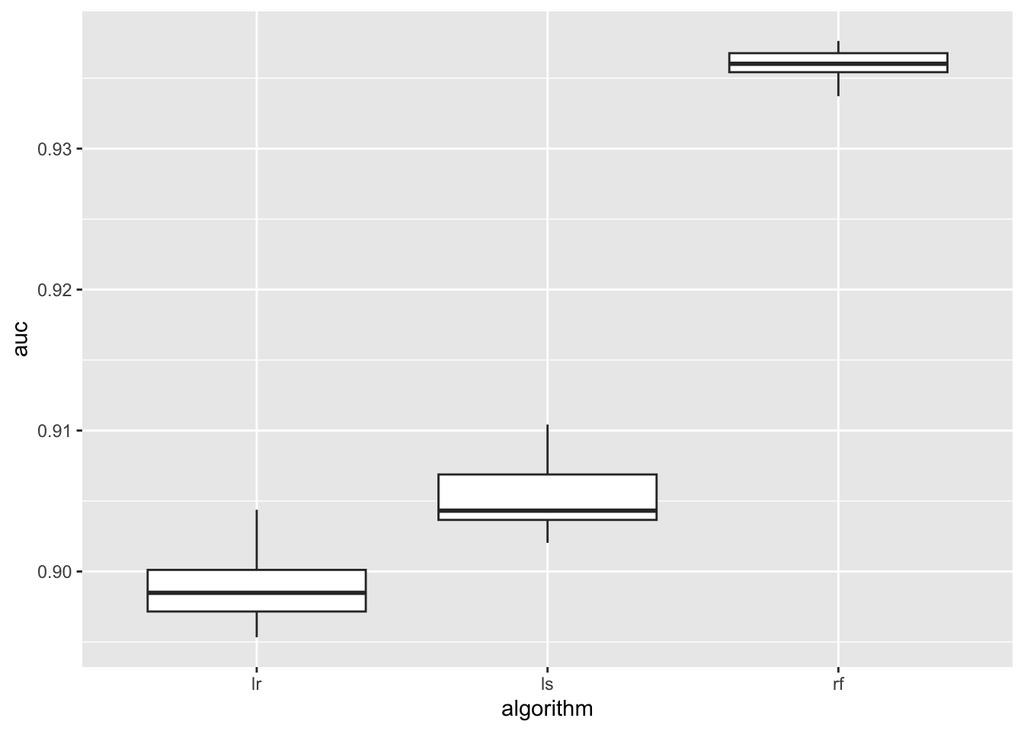

```r
perturbed_jc_performance |>
  ggplot() +
  geom_boxplot(aes(x = algorithm, y = auc))
```

And then the true positive rate (based on the 0.161 cutoff):

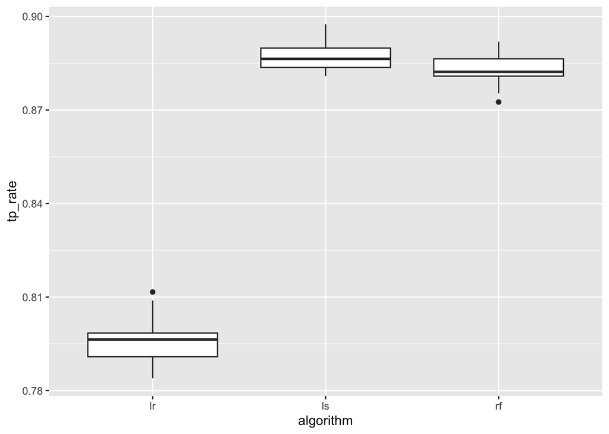

```r
perturbed_jc_performance |>
  ggplot() +
  geom_boxplot(aes(x = algorithm, y = tp_rate))
```

And then the true negative rate (based on the 0.161 cutoff):

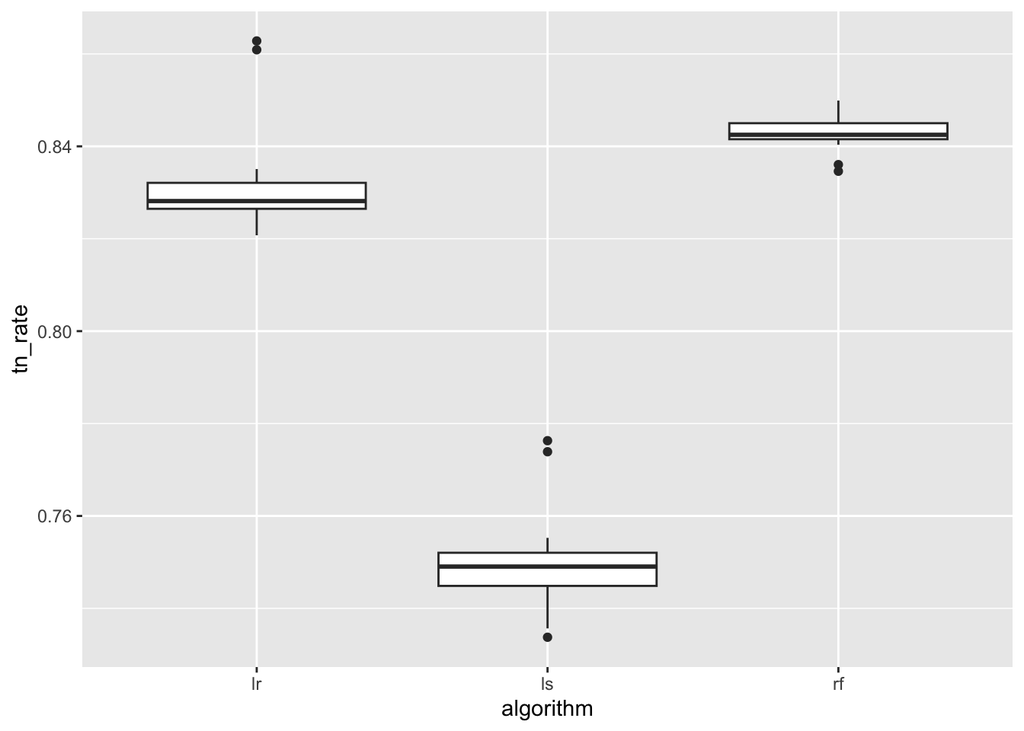

```r
perturbed_jc_performance |>
  ggplot() +
  geom_boxplot(aes(x = algorithm, y = tn_rate))
```

and the accuracy (based on the 0.161 cutoff):

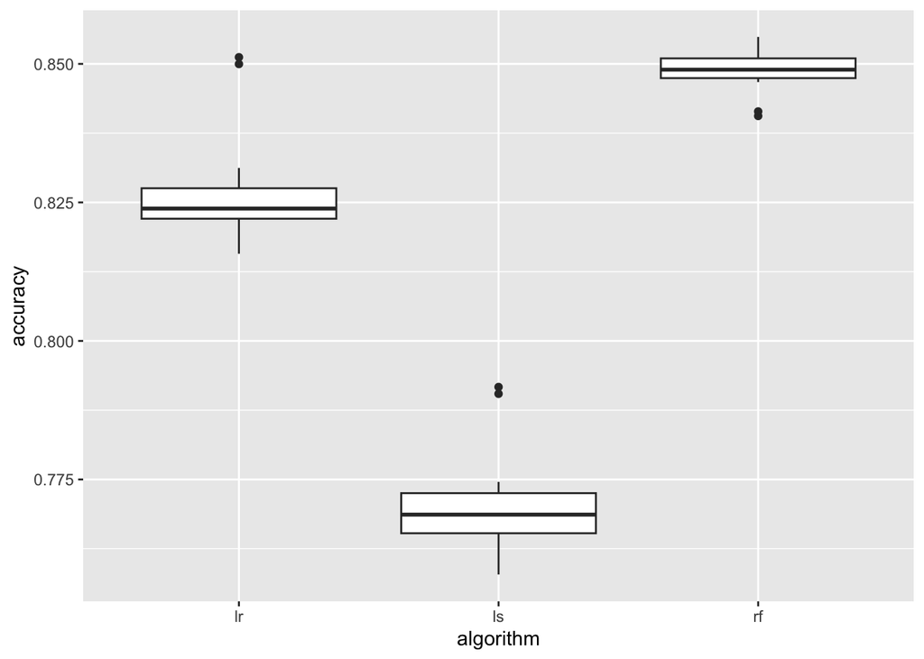

```r
perturbed_jc_performance |>
  ggplot() +
  geom_boxplot(aes(x = algorithm, y = accuracy))
```

### 3.1 Test set evaluation

To evaluate the ensemble, let’s compute the ensemble predictions for each of the *test set* data points.

```r
perturbed_jc_pred_test <- perturbed_jc_pred |>
  ungroup() %>%
  # select the relevant validation set prediction performance
  select(
    # judgment calls
    numeric_to_cat, month_numeric, log_page, remove_extreme,
    # val predictions
    pred_test_ls, pred_test_lr, pred_test_rf,
    # val truth
    true_test, id_test) |>
  # pivot to a long-form version with one column for all the predictions
  pivot_longer(cols = c("pred_test_ls", "pred_test_lr", "pred_test_rf"),
               names_to = "algorithm",
               values_to = "pred_test",
               names_prefix = "pred_test_") %>%
   rowwise() %>%
  # compute the binary predictions
  mutate(pred_test_binary = list(factor(as.numeric(pred_test >= 0.161), levels = c(1, 0)))) |>
  # add performance metrics for each perturbed fit
  # expand the nested list columns
  unnest(c("true_test", "id_test", "pred_test", "pred_test_binary"))
```

Since the unthresholded prediction output of each algorithms does not necessarily have the same meaning (specifically, the LS output is not actually a class probability prediction), we will only compute binary predictions using a majority vote:

```r
perturbed_jc_pred_ensemble_test <- perturbed_jc_pred_test |>
  # compute the majority vote prediction for each session
  group_by(id_test) |>
  summarise(ensemble_pred_test = factor(as.numeric(sum(pred_test_binary == 1) >= n() / 2), levels = c(1, 0)),
            true_test = unique(true_test)) |>
  ungroup()

head(perturbed_jc_pred_ensemble_test)
```

```
# A tibble: 6 × 3
  id_test ensemble_pred_test true_test
    <int> <fct>              <fct>
1       1 0                  0
2       2 0                  0
3       4 0                  0
4      10 0                  0
5      28 0                  0
6      33 0                  0
```

The performance of the ensemble predictions can then be computed using the regular metrics

```r
perturbed_jc_pred_ensemble_test %>%
  # add performance metrics for each perturbed fit
  summarise(accuracy = accuracy_vec(true_test, ensemble_pred_test),
            tp_rate = sens_vec(true_test, ensemble_pred_test),
            tn_rate = spec_vec(true_test, ensemble_pred_test))
```

```
# A tibble: 1 × 3
  accuracy tp_rate tn_rate
     <dbl>   <dbl>   <dbl>
1    0.822   0.828   0.821
```

Indeed, the test set correlation performance of the ensemble fit is slightly worse (lower) than the “single best” fit across all measures.